# Assignment 3

Lange Luntao

12/7/2020

*Using the datasets we have encountered so far in the curriculum (American Communities Survey, CalEnviroScreen, 500 Cities, PG&E), and any other datasets you can access publicly, conduct a series of regression analyses that shed light on an urban topic of interest to you. Given that this may be your first data-driven statistical analysis, approach this exercise as a “walk-before-you-run” kind of experience; you will certainly be able to practice more complicated statistical analyses throughout the rest of this curriculum and your urban work. Closely follow the guidelines below:*

*- Select one (or at most, two) outcomes of interest that can be measured at the CBG, tract, or ZCTA level in the Bay Area. They must be continuous variables (like % of households in poverty) at this scale of analysis. At least one of the outcomes must also be available in the PUMS data at the individual or household level, so that one of your analyses can make use of PUMS data specifically. At this scale of analysis, the outcome can still be a continuous variable (like individual income) or convert to a categorical variable that can be made binary (like completing a college degree or not).*

For this assignment, I chose to focus on census tracts within the 12 CA counties which comprise the San Joaquin Valley region, as determined by the State’s new COVID-19 closure thresholds. [Map of San Joaquin Valley region, as determined by State](https://www.sacbee.com/latest-news/wm8v2u/picture247595975/alternates/FREE_768/FINAL%20CORRECTED%20WEB%20COVID%20REGION.jpg)

I was interested in comparing the percentage of population in each census tract that have a bachelor’s degree or higher vs. the percent with some form of medical insurance. To get at this data, I used items contained in B27019, health insurance coverage status and type by age and educational attainment. The data is broken into two general age brackets - folks aged 25 to 64 and those 65+ (presumably because once folks hit the age of 65, they become eligible for MediCare). I isolated the percentage of folks between 25 - 64 with bachelor’s degrees/higher in each census tract (roughly normally distributed, ranging from 0 to approx. 55%) and compared them against the broad percent with insurance (roughly normally distributed, ranging from about 40% to 100%, with the majority of census tracts between 60% and 80% insured.)

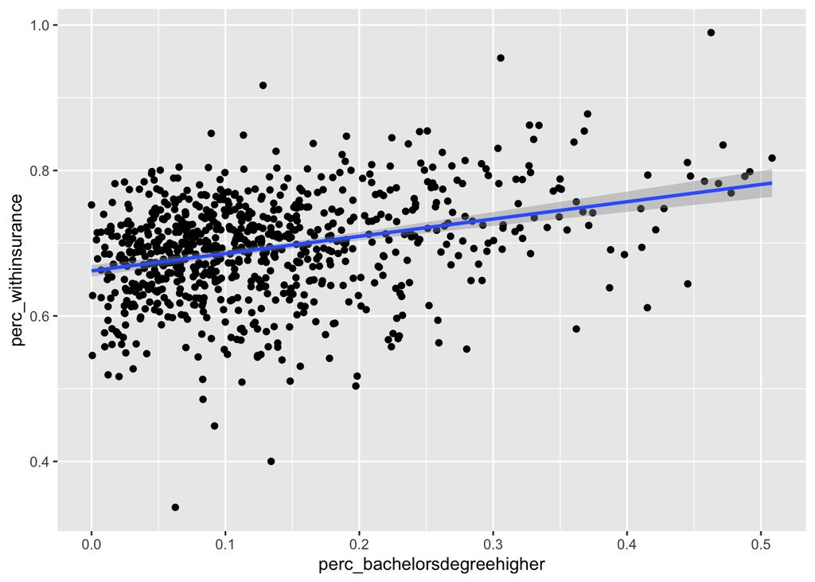

```r
### brainstorm: educational attainment vs health insurance status
Sys.setenv(CENSUS_KEY="8a30b488e19d78df02c748f4833ec25ed94fffa6")

acs_vars_2018_5yr <-
  listCensusMetadata(
    name = "2018/acs/acs5",
    type = "variables"
  )


sj_insurance_edu_tract <-
  getCensus(
    name = "acs/acs5",
    vintage = 2018,
    region = "tract:*",
    regionin = "state:06+county:009,019,029,031,039,043,047,069,077,099,107,109",
    vars = c(
      "B27019_018E",
      "B27019_001E",
      "B27019_019E",
      "B27019_009E",
      "B27019_004E",
      "B27019_014E"
    )
  ) %>%
  transmute(
    tract = paste0(state, county, tract),
    perc_bachelorsdegreehigher = B27019_018E / B27019_001E,
    perc_withinsurance = (B27019_019E + B27019_009E + B27019_004E + B27019_014E) / B27019_001E
  ) %>%
  filter(
    !is.na(perc_bachelorsdegreehigher),
    !is.na(perc_withinsurance)
  )


ggplot(
    data = sj_insurance_edu_tract,
    aes(
      x = perc_bachelorsdegreehigher,
      y = perc_withinsurance
    )
  ) +
  geom_point() +
  geom_smooth(method = "lm")
```

```r
model <- lm(perc_withinsurance ~ perc_bachelorsdegreehigher, sj_insurance_edu_tract)

summary(model)
```

```
##
## Call:
## lm(formula = perc_withinsurance ~ perc_bachelorsdegreehigher,
##     data = sj_insurance_edu_tract)
##
## Residuals:
##      Min       1Q   Median       3Q      Max
## -0.33998 -0.03667  0.00754  0.04566  0.22454
##
## Coefficients:
##                            Estimate Std. Error t value Pr(>|t|)
## (Intercept)                0.661990   0.004064 162.875   <2e-16 ***
## perc_bachelorsdegreehigher 0.237548   0.024998   9.503   <2e-16 ***
## ---
## Signif. codes:  0 '***' 0.001 '**' 0.01 '*' 0.05 '.' 0.1 ' ' 1
##
## Residual standard error: 0.06783 on 788 degrees of freedom
## Multiple R-squared:  0.1028, Adjusted R-squared:  0.1017
## F-statistic:  90.3 on 1 and 788 DF,  p-value: < 2.2e-16
```

The regression analysis indicates that there is indeed a statistically significant relationship (at a less than .001 p-value) between an increasing percentage of residents that have a bachelors degree or higher and an increasing percentage with health insurance in these census tracts. Holding all other things equal, it appears that having a bachelor’s degree is associated with an additional 23.7% likelihood of possessing health insurance. There is wide variability - bachelor’s degree possession only describes 10% of the variance in insurance (from the r-squared), but it is a significant contributing. factor.

*- Perform an individual or household level multiple regression analysis (with PUMS data for PUMAS in the Bay Area) using one of your outcomes of interest as the dependent variable and at least two independent variables (like language ability or commute time), which should be chosen based on some brief open-ended exploration of academic papers, news articles, or personal anecdotes that suggest a statistical relationship may be found between the independent and dependent variables. Compare your findings to those of your reviewed resources (keep in mind that if your geography and/or time period of analysis is different from that of your sources, those can be sources of differences in findings). Carefully describe your position on whether a causal claim can be made based on the results of your analysis, and feel free to comment on the degree to which your reviewed sources communicate correlation vs. causation in the same way. Be sure to make use of weights properly in the PUMS data.*

For this part of the assignment, I aimed to further investigate the contributing factors and barriers to residents of the Central Valley in accessing health insurance. We established (above) that there is a relationship between educational attainment and health insurance status. We also know from a wide range of studies and news accounts that immigrants - and particularly those without citizenship status - encounter major barriers in accessing healthcare. This has become even more pronounced equity consideration during the COVID-19 pandemic - without access to trusted and easily-accessed COVID testing and treatment, residents risk further endangering their own health, their families or other household members, and entire community.

Literature referenced - [Health Coverage of Undocumented Immigrants - Kaiser Family Foundation](https://www.kff.org/racial-equity-and-health-policy/issue-brief/health-coverage-and-care-of-undocumented-immigrants/) - [Health Coverage of Immigrants - Kaiser Family Foundation](https://www.kff.org/racial-equity-and-health-policy/fact-sheet/health-coverage-of-immigrants/) - [Left Out: Immigrants’ Access to Health Care and Insurance](https://www.healthaffairs.org/doi/full/10.1377/hlthaff.20.1.247) - [Medical News Today - US election result: Impact on healthcare for undocumented communities](https://www.medicalnewstoday.com/articles/us-election-result-impact-on-healthcare-for-undocumented-communities)

To hone in on this more, I chose to build a multiple regression analysis of individuals in the San Joaquin Valley comparing a) health insurance status (possessing health insurance or not), b) educational attainment (possessing a bachelor’s degree and above, or not), and c) citizenship status (possessing US citizenship or not).

```r
ca_pumas <-
  pumas("CA", cb = T, progress_bar = F)

pums_vars_2018_distinct_pp <-
  pums_vars_2018 %>%
  distinct(var_code, var_label, data_type, level) %>%
  filter(level == "person")

### isolating to the San Joaquin Valley counties

sj_valley_names <-
  c(
    "Calaveras",
    "Fresno",
    "Kern",
    "Kings",
    "Madera",
    "Mariposa",
    "Merced",
    "San Benito",
    "San Joaquin",
    "Stanislaus",
    "Tulare",
    "Tuolumne"
  )

sj_counties <-
  counties("CA", cb = T, progress_bar = F) %>%
  filter(NAME %in% sj_valley_names)

sj_pumas <-
  ca_pumas %>%
  st_centroid() %>%
  .[sj_counties, ] %>%
  st_set_geometry(NULL) %>%
  left_join(ca_pumas %>% select(GEOID10)) %>%
  st_as_sf()
```

```
## although coordinates are longitude/latitude, st_intersects assumes that they are planar
## although coordinates are longitude/latitude, st_intersects assumes that they are planar
```

```r
sj_pums <-
  ca_pums %>%
  filter(PUMA %in% sj_pumas$PUMACE10)

sj_pums_example <-
  sj_pums %>%
  filter(!duplicated(SERIALNO)) %>%
  mutate(
    healthinsurance = ifelse(
      (HICOV==1),
      PWGTP,
      0),
    citizen = ifelse(
      (CIT!=5),
      PWGTP,
      0),
    collegegrad = ifelse(
      (SCHL==20)|(SCHL==21)|(SCHL==22)|(SCHL==23)|(SCHL==24),
      PWGTP,
      0
    )
  )
```

After calling all of the PUMS in the San Joaquin Valley and weighting the population sizes, I prepared a multiple regression comparing individuals who have health insurance to citizenship status and if they were a college graduate or not. I turned each of these statuses into binaries (posession of health insurance or not / citizen or not / college grad or not), and performed the multiple regression on the weighted values.

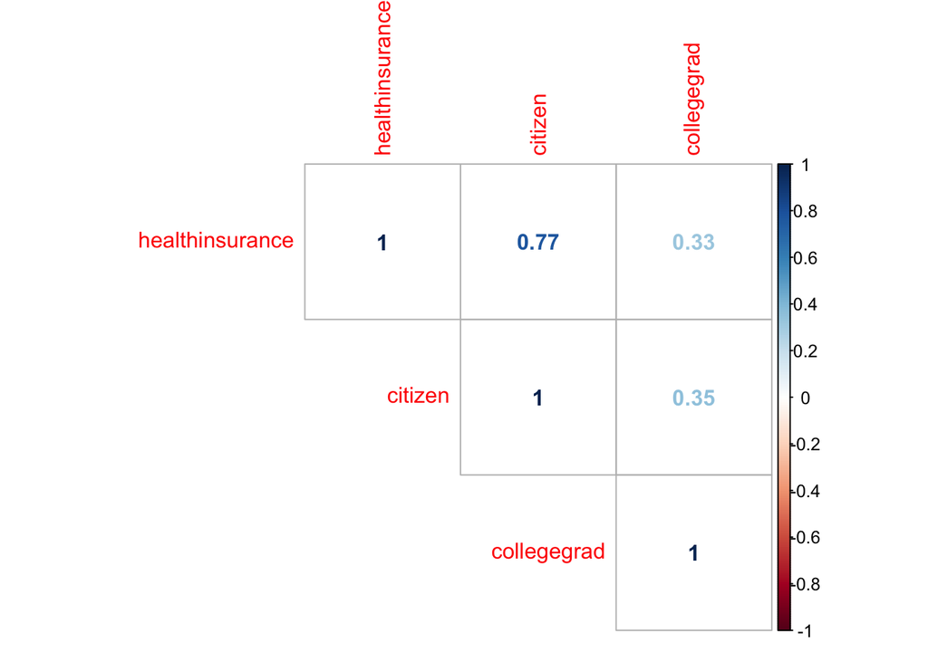

```r
correlationplot <- sj_pums_example %>%
  select(
    healthinsurance,
    citizen,
    collegegrad
  ) %>%
  cor()

corrplot(
  correlationplot,
  method = "number",
  type = "upper"
)
```

```r
model <- lm(healthinsurance ~ citizen+collegegrad, sj_pums_example)

summary(model)
```

```
##
## Call:
## lm(formula = healthinsurance ~ citizen + collegegrad, data = sj_pums_example)
##
## Residuals:
##      Min       1Q   Median       3Q      Max
## -137.712   -2.764   -1.393    1.045  182.561
##
## Coefficients:
##             Estimate Std. Error t value Pr(>|t|)
## (Intercept) 4.438913   0.053663   82.72   <2e-16 ***
## citizen     0.761559   0.002547  299.01   <2e-16 ***
## collegegrad 0.086140   0.003477   24.77   <2e-16 ***
## ---
## Signif. codes:  0 '***' 0.001 '**' 0.01 '*' 0.05 '.' 0.1 ' ' 1
##
## Residual standard error: 9.829 on 71766 degrees of freedom
## Multiple R-squared:  0.6019, Adjusted R-squared:  0.6019
## F-statistic: 5.426e+04 on 2 and 71766 DF,  p-value: < 2.2e-16
```

The regression plot indicates there is a statistically significant relationship between the combination of health insurance, being a citizen, and being a college graduate. In this analysis, it seems that being a citizen seems to have better predictive power (on having health insurance) compared to educational attainment. This does confirm the literature review above that not being a citizen remains a strongly correlated factor in whether or not a resident has health insurance (perhaps more so than educational attainment).

This does not indicate causation, but could indicate correlation at the 1% significance level (or greater).

*- Perform at least one additional multiple regression analysis at the CBG, tract, or ZCTA level in the Bay Area, at which you may choose to use a similar outcome as the first analysis or a different one. Again, select at least two independent variables. Both independent and dependent variables can now come from other datasets besides the ACS, as long as they match the geographic scale of analysis. You are more than welcome to try matching this analysis with the first one as much as possible, so as to explicitly compare the results of an individual vs. ecological scale of analysis, or make this analysis completely different (in which case you should prepare a second set of literature review).*

I chose to go back to the original simple regression, and ask - does citizenship status help explain a greater amount of variance when considering the relationship between educational attainment and health insurance status? I collected the ACS data from 2018 asking similar questions - the percentage of residents in each census tract that have insurance, the percentage that are citizens, and the percentage that have a bachelor’s degree or higher.

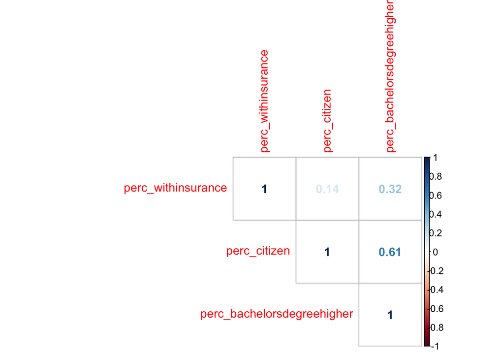

```r
acs_vars_2018_5yr <-
  listCensusMetadata(
    name = "2018/acs/acs5",
    type = "variables"
  )

sj_multipleregression_tract <-
  getCensus(
    name = "acs/acs5",
    vintage = 2018,
    region = "tract:*",
    regionin = "state:06+county:009,019,029,031,039,043,047,069,077,099,107,109",
    vars = c(
      "B27019_018E",
      "B27019_001E",
      "B27019_019E",
      "B27019_009E",
      "B27019_004E",
      "B27019_014E",
      "B27020_013E",
      "B27020_001E"
    )
  ) %>%
  transmute(
    tract = paste0(state, county, tract),
    perc_bachelorsdegreehigher = B27019_018E / B27019_001E,
    perc_withinsurance = (B27019_019E + B27019_009E + B27019_004E + B27019_014E) / B27019_001E,
    perc_citizen = 1-(B27020_013E / B27020_001E)
  ) %>%
  filter(
    !is.na(perc_bachelorsdegreehigher),
    !is.na(perc_withinsurance),
    !is.na(perc_citizen)
  )


correlationplot <- sj_multipleregression_tract %>%
  select(
    perc_withinsurance,
    perc_citizen,
    perc_bachelorsdegreehigher,
  ) %>%
  cor()

corrplot(
  correlationplot,
  method = "number",
  type = "upper"
)
```

```r
model <- lm(perc_withinsurance ~ perc_citizen+perc_bachelorsdegreehigher, sj_multipleregression_tract)

summary(model)
```

```
##
## Call:
## lm(formula = perc_withinsurance ~ perc_citizen + perc_bachelorsdegreehigher,
##     data = sj_multipleregression_tract)
##
## Residuals:
##      Min       1Q   Median       3Q      Max
## -0.33691 -0.03790  0.00631  0.04520  0.23176
##
## Coefficients:
##                            Estimate Std. Error t value Pr(>|t|)
## (Intercept)                 0.71594    0.02660  26.913   <2e-16 ***
## perc_citizen               -0.06768    0.03299  -2.052   0.0405 *
## perc_bachelorsdegreehigher  0.27700    0.03150   8.794   <2e-16 ***
## ---
## Signif. codes:  0 '***' 0.001 '**' 0.01 '*' 0.05 '.' 0.1 ' ' 1
##
## Residual standard error: 0.0677 on 787 degrees of freedom
## Multiple R-squared:  0.1076, Adjusted R-squared:  0.1053
## F-statistic: 47.44 on 2 and 787 DF,  p-value: < 2.2e-16
```

This multiple regression analysis, based on the ACS daata within census tracts, complicates the picture we took away from the PUMS data above. Here we see a weak relationship between the percentage of citizens in a census tract and the percent of residents with insurance. This indicates a stronger relationship between attaining a bachelor’s degree or higher and possessing citizenship.

This makes me wonder: - Could the ecological rather than individual focus obscure the number of undocumented residents without insurance? In this model, population size of relative census tracts is not weighted. Undocumented residents without insurance could be densely concentrated in a small number of census tracts, which would affect the strength of the regression. - Could the ACS ‘undercount’ noncitizens? We know that there has been significant controversy in recent years over the inclusion of more detailed citizenship questions. Could that have suprressed the numbers included re: noncitizens?

For good measure, I completed this multiple regression one more time with data from two years prior - 2016.

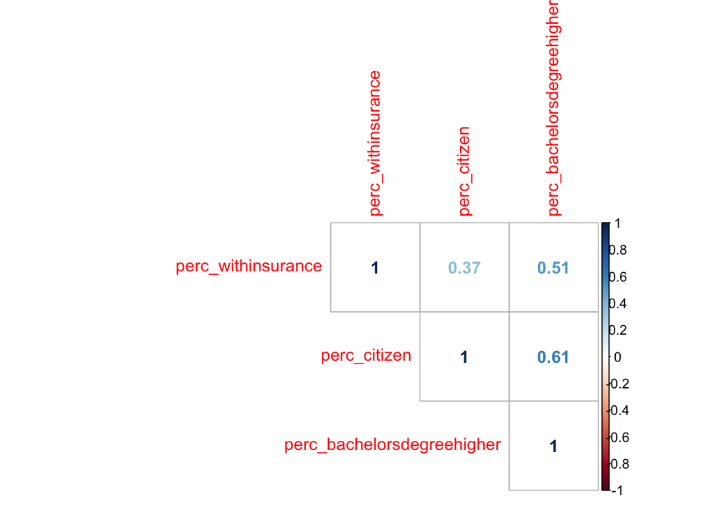

```r
acs_vars_2016_5yr <-
  listCensusMetadata(
    name = "2016/acs/acs5",
    type = "variables"
  )

sj_multipleregression16_tract <-
  getCensus(
    name = "acs/acs5",
    vintage = 2016,
    region = "tract:*",
    regionin = "state:06+county:009,019,029,031,039,043,047,069,077,099,107,109",
    vars = c(
      "B27019_018E",
      "B27019_001E",
      "B27019_019E",
      "B27019_009E",
      "B27019_004E",
      "B27019_014E",
      "B27020_013E",
      "B27020_001E"
    )
  ) %>%
  transmute(
    tract = paste0(state, county, tract),
    perc_bachelorsdegreehigher = B27019_018E / B27019_001E,
    perc_withinsurance = (B27019_019E + B27019_009E + B27019_004E + B27019_014E) / B27019_001E,
    perc_citizen = 1-(B27020_013E / B27020_001E)
  ) %>%
  filter(
    !is.na(perc_bachelorsdegreehigher),
    !is.na(perc_withinsurance),
    !is.na(perc_citizen)
  )


correlationplot <- sj_multipleregression16_tract %>%
  select(
    perc_withinsurance,
    perc_citizen,
    perc_bachelorsdegreehigher,
  ) %>%
  cor()

corrplot(
  correlationplot,
  method = "number",
  type = "upper"
)
```

```r
model <- lm(perc_withinsurance ~ perc_citizen+perc_bachelorsdegreehigher, sj_multipleregression16_tract)

summary(model)
```

```
##
## Call:
## lm(formula = perc_withinsurance ~ perc_citizen + perc_bachelorsdegreehigher,
##     data = sj_multipleregression16_tract)
##
## Residuals:
##       Min        1Q    Median        3Q       Max
## -0.308775 -0.044131  0.001907  0.044973  0.264189
##
## Coefficients:
##                            Estimate Std. Error t value Pr(>|t|)
## (Intercept)                 0.53244    0.02630  20.241   <2e-16 ***
## perc_citizen                0.08073    0.03278   2.463    0.014 *
## perc_bachelorsdegreehigher  0.37700    0.03192  11.809   <2e-16 ***
## ---
## Signif. codes:  0 '***' 0.001 '**' 0.01 '*' 0.05 '.' 0.1 ' ' 1
##
## Residual standard error: 0.06899 on 787 degrees of freedom
## Multiple R-squared:  0.2686, Adjusted R-squared:  0.2667
## F-statistic: 144.5 on 2 and 787 DF,  p-value: < 2.2e-16
```